# A quick sketch to (roughly) map the history of OSM edits in Kathmandu valley

We've all seen those awesome [“Year of Edits” videos](http://www.youtube.com/watch?v=lsReygHnXAU) of OSM. As the OSM community in Nepal and Kathmandu are growing, people have thought of doing similar work to visualize the growth of OSM in Nepal / Kathmandu. I'm happy to report that [OSM Nepal](http://www.osmnepal.org/) is working on that long term project. But as that project will likely take a while, I started to think that I can do approximate versions of that project using R, and learn R's [osmar](http://osmar.r-forge.r-project.org/) library while at it. What follows is a documentation of my v1 effort, written in a style that I hope is replicable.

## In the beginning…

I started with a “metro” extract of the Kathmandu valley (from http://metro.teczno.com/#kathmandu – thanks [@michalmigurski](http://twitter.com/michalmigurski)!), and tried to open it using the `osmar` package. It took too long, though, so I had to open up only a small bounding box within Kathmandu to start playing with what I can do with this data in R. After creating the osmar object, I plot it, because it is so beautiful!

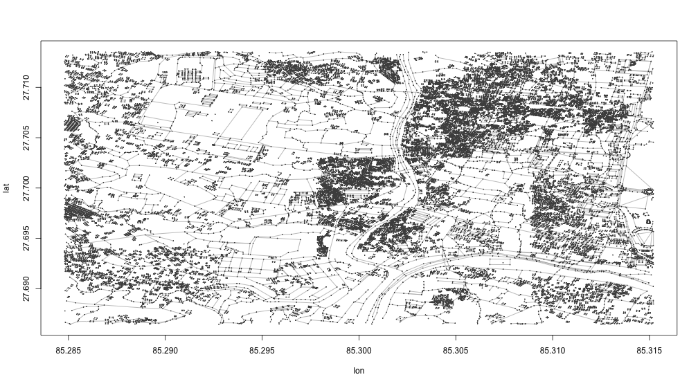

```r
require(devtools)
load_all("~/Code/lib/osmar1.1-5")  # my custom version of osmar
ktm_bbox <- center_bbox(85.3, 27.7, 3000, 3000)
src = osmsource_osmosis(file = "/Users/prabhaspokharel/Downloads/kathmandu.osm")
ktm <- get_osm(ktm_bbox, source = src)
plot(ktm)
```

```r
require(sp)
p <- as_sp(ktm, "poly")
# l <- as_sp(ktm, 'lines')
n <- as_sp(ktm, "points")
```

## The big approximation

I mentioned that I was going to do an approximate version of a history time-lapse. Well, at least in this v1, one of the approximations is that I'm not doing all of Kathmandu, let alone all of Nepal.

There is another approximation here though, which is that I'm actually going to ignore the historical edits, and just treat all nodes / ways as if *they were created at their last edited date*. This simplifies the work a lot, since all I have to deal with is one OSM file, I don't need to touch the history at all. Yes, this is a big approximation, but lets actually check how big:

```r
sum(n@data$version == 1)/nrow(n@data)
```

```
## [1] 0.913
```

```r
sum(n@data$version == 1)/sum(n@data$version)
```

```
## [1] 0.7742
```

91% of all the nodes are in version 1. That means that once created, they were never edited. So the time lapse is correct for 91% of the objects in the map. And I'm capturing 77% of the edits that were made to this portion of the map. While not great, I'm willing to live with this, given this work is as simple as it is.

## Objective 1: Timelapse of when buildings were last edited

Okay, another simplification: lets begin with just polygons, and make a rough plot of when they were last edited, to see whether we're going to get anything out of this at all:

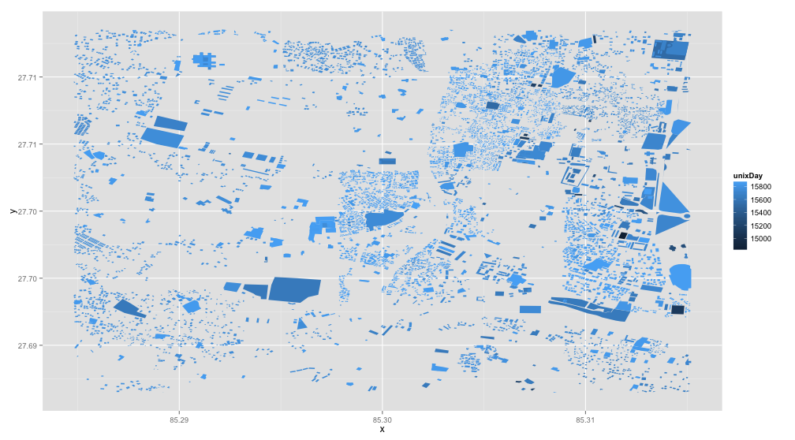

```r
require(ggplot2)
require(scales)
require(lubridate)
# create a 'fortified' version of the SpatialPolygonsDataFrame to make it
# ggplot friendly, and merge that data in the dataframe into that fortified
# data frame
pp <- merge(p@data, fortify(p), by = "id")
# unfortunately, ggplot doesn't do color- or fill-scales with timestamps, so
# we'll have to come up with a numerical representation
pp$unixDay <- as.double(as.Date(pp$timestamp))
ggplot() + geom_map(data = pp, aes(map_id = id, fill = unixDay), map = pp) +
    expand_limits(x = pp$long, y = pp$lat)
```

Okay, we've got something really really rough. All the polygons in this area of Kathmandu, colored by when they were last edited. Good start!

Now, we want to create a single plot that we think will work well within the context of a time-lapse. First, we need to choose how long a time each snapshot in the time-lapse takes. I chose a week. After that, for a given week, we have to choose how to plot a 'still-frame' in the time-lapse. After much iteration, I came to the following idea: I'll color buildings added (or rather last-edited) as bright yellow, and the rest of the map grey. Here is the code below; I have chosen `week_start` to be the median week, to start iterating.

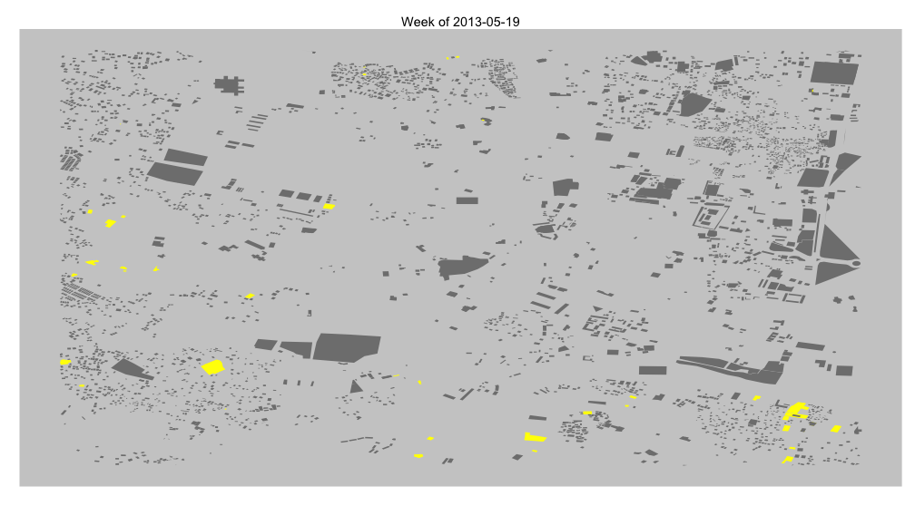

```r
pp$week <- round_date(pp$timestamp, unit = "week")
toUnixDay <- function(x) {
    as.double(as.Date(x))
}
blank_theme <- function() {
    theme(axis.text = element_blank(), axis.ticks = element_blank(), axis.title = element_blank(),
        panel.grid = element_blank(), panel.background = element_rect(fill = "#cccccc"),
        legend.position = "none")
}

plotMe <- function(week_start, pp, debug = F) {
    week_end <- week_start + weeks(1)
    until_this_week <- subset(pp, unixDay < toUnixDay(week_end))
    until_this_week$before_this_week <- until_this_week$unixDay >= toUnixDay(week_start)
    p <- ggplot() + geom_map(data = until_this_week, aes(map_id = id, fill = before_this_week),
        map = until_this_week) + expand_limits(x = pp$long, y = pp$lat) + labs(title = paste("Week of",
        week_start)) + scale_fill_manual(values = c("grey50", "yellow")) + blank_theme()

    print(p)  # i find that print(p) when p is a ggplot object actually helps make sure it
    # is printed out into the graphical device, particularly when it is a pdf.
    if (debug) {
        print(paste("That was week: ", week_start))
    }
}


plotMe(median(pp$week), pp)
```

Looking pretty good. So lets produce a multi-page pdf, going through all the weeks. The pdf won't show up here, but you can browse this repo to find it. But, what I do next is that I load up that pdf into video-editing software that allows you to create a pdf slideshow (I use [Camtasia](http://www.techsmith.com/camtasia.html), which is made for screen captures, but also serves me as a light video editor).

```r
lastWeek <- max(pp$week)
week_start <- min(pp$week)
pdf("plots_daily.pdf")
while (week_start < lastWeek) {
    week_start <- min(subset(pp, week > week_start)$week)
    plotMe(week_start, pp)
}
graphics.off()
```

Youtube embed:

[video not shown]